# Risk Factor Analysis

## Outcome Variable

**Outcome Variable:** sstunted

## Predictor Variables

**Intervention Variable:** predfeed36

**Adjustment Set:**

unadjusted

## Stratifying Variables

The analysis was stratified on these variable(s):

- agecat
- studyid
- country

## Data Summary

| agecat | studyid | country | predfeed36 | sstunted | n_cell | n |
| --- | --- | --- | --- | --- | --- | --- |
| Birth | EE | PAKISTAN | 1 | 0 | 2 | 7 |
| Birth | EE | PAKISTAN | 1 | 1 | 1 | 7 |
| Birth | EE | PAKISTAN | 0 | 0 | 4 | 7 |
| Birth | EE | PAKISTAN | 0 | 1 | 0 | 7 |
| Birth | GMS-Nepal | NEPAL | 1 | 0 | 409 | 526 |
| Birth | GMS-Nepal | NEPAL | 1 | 1 | 13 | 526 |
| Birth | GMS-Nepal | NEPAL | 0 | 0 | 101 | 526 |
| Birth | GMS-Nepal | NEPAL | 0 | 1 | 3 | 526 |
| Birth | JiVitA-3 | BANGLADESH | 1 | 0 | 7467 | 10681 |
| Birth | JiVitA-3 | BANGLADESH | 1 | 1 | 867 | 10681 |
| Birth | JiVitA-3 | BANGLADESH | 0 | 0 | 2093 | 10681 |
| Birth | JiVitA-3 | BANGLADESH | 0 | 1 | 254 | 10681 |
| Birth | JiVitA-4 | BANGLADESH | 1 | 0 | 1852 | 2517 |
| Birth | JiVitA-4 | BANGLADESH | 1 | 1 | 147 | 2517 |
| Birth | JiVitA-4 | BANGLADESH | 0 | 0 | 453 | 2517 |
| Birth | JiVitA-4 | BANGLADESH | 0 | 1 | 65 | 2517 |
| Birth | MAL-ED | BANGLADESH | 1 | 0 | 70 | 221 |
| Birth | MAL-ED | BANGLADESH | 1 | 1 | 2 | 221 |
| Birth | MAL-ED | BANGLADESH | 0 | 0 | 144 | 221 |
| Birth | MAL-ED | BANGLADESH | 0 | 1 | 5 | 221 |
| Birth | MAL-ED | BRAZIL | 1 | 0 | 7 | 65 |
| Birth | MAL-ED | BRAZIL | 1 | 1 | 1 | 65 |
| Birth | MAL-ED | BRAZIL | 0 | 0 | 55 | 65 |
| Birth | MAL-ED | BRAZIL | 0 | 1 | 2 | 65 |
| Birth | MAL-ED | INDIA | 1 | 0 | 4 | 42 |
| Birth | MAL-ED | INDIA | 1 | 1 | 0 | 42 |
| Birth | MAL-ED | INDIA | 0 | 0 | 36 | 42 |
| Birth | MAL-ED | INDIA | 0 | 1 | 2 | 42 |
| Birth | MAL-ED | NEPAL | 1 | 0 | 1 | 26 |
| Birth | MAL-ED | NEPAL | 1 | 1 | 0 | 26 |

[output cut: 114 more lines]

The following strata were considered:

- agecat: 24 months, studyid: EE, country: PAKISTAN
- agecat: 24 months, studyid: GMS-Nepal, country: NEPAL
- agecat: 24 months, studyid: JiVitA-3, country: BANGLADESH
- agecat: 24 months, studyid: JiVitA-4, country: BANGLADESH
- agecat: 24 months, studyid: LCNI-5, country: MALAWI
- agecat: 24 months, studyid: MAL-ED, country: BANGLADESH
- agecat: 24 months, studyid: MAL-ED, country: BRAZIL
- agecat: 24 months, studyid: MAL-ED, country: INDIA
- agecat: 24 months, studyid: MAL-ED, country: NEPAL
- agecat: 24 months, studyid: MAL-ED, country: PERU
- agecat: 24 months, studyid: MAL-ED, country: SOUTH AFRICA
- agecat: 24 months, studyid: MAL-ED, country: TANZANIA, UNITED REPUBLIC OF
- agecat: 6 months, studyid: EE, country: PAKISTAN
- agecat: 6 months, studyid: GMS-Nepal, country: NEPAL
- agecat: 6 months, studyid: JiVitA-3, country: BANGLADESH
- agecat: 6 months, studyid: JiVitA-4, country: BANGLADESH
- agecat: 6 months, studyid: LCNI-5, country: MALAWI
- agecat: 6 months, studyid: MAL-ED, country: BANGLADESH
- agecat: 6 months, studyid: MAL-ED, country: BRAZIL
- agecat: 6 months, studyid: MAL-ED, country: INDIA
- agecat: 6 months, studyid: MAL-ED, country: NEPAL
- agecat: 6 months, studyid: MAL-ED, country: PERU
- agecat: 6 months, studyid: MAL-ED, country: SOUTH AFRICA
- agecat: 6 months, studyid: MAL-ED, country: TANZANIA, UNITED REPUBLIC OF
- agecat: 6 months, studyid: SAS-FoodSuppl, country: INDIA
- agecat: Birth, studyid: EE, country: PAKISTAN
- agecat: Birth, studyid: GMS-Nepal, country: NEPAL
- agecat: Birth, studyid: JiVitA-3, country: BANGLADESH
- agecat: Birth, studyid: JiVitA-4, country: BANGLADESH
- agecat: Birth, studyid: MAL-ED, country: BANGLADESH
- agecat: Birth, studyid: MAL-ED, country: BRAZIL
- agecat: Birth, studyid: MAL-ED, country: INDIA
- agecat: Birth, studyid: MAL-ED, country: NEPAL
- agecat: Birth, studyid: MAL-ED, country: PERU
- agecat: Birth, studyid: MAL-ED, country: SOUTH AFRICA
- agecat: Birth, studyid: MAL-ED, country: TANZANIA, UNITED REPUBLIC OF

### Dropped Strata

Some strata were dropped due to rare outcomes:

- agecat: Birth, studyid: EE, country: PAKISTAN
- agecat: Birth, studyid: GMS-Nepal, country: NEPAL
- agecat: Birth, studyid: MAL-ED, country: BANGLADESH
- agecat: Birth, studyid: MAL-ED, country: BRAZIL
- agecat: Birth, studyid: MAL-ED, country: INDIA
- agecat: Birth, studyid: MAL-ED, country: NEPAL
- agecat: Birth, studyid: MAL-ED, country: PERU
- agecat: Birth, studyid: MAL-ED, country: SOUTH AFRICA
- agecat: Birth, studyid: MAL-ED, country: TANZANIA, UNITED REPUBLIC OF
- agecat: 6 months, studyid: EE, country: PAKISTAN
- agecat: 6 months, studyid: LCNI-5, country: MALAWI
- agecat: 6 months, studyid: MAL-ED, country: BANGLADESH
- agecat: 6 months, studyid: MAL-ED, country: BRAZIL
- agecat: 6 months, studyid: MAL-ED, country: INDIA
- agecat: 6 months, studyid: MAL-ED, country: NEPAL
- agecat: 6 months, studyid: MAL-ED, country: PERU
- agecat: 6 months, studyid: MAL-ED, country: SOUTH AFRICA
- agecat: 6 months, studyid: MAL-ED, country: TANZANIA, UNITED REPUBLIC OF
- agecat: 6 months, studyid: SAS-FoodSuppl, country: INDIA
- agecat: 24 months, studyid: EE, country: PAKISTAN
- agecat: 24 months, studyid: LCNI-5, country: MALAWI
- agecat: 24 months, studyid: MAL-ED, country: BRAZIL
- agecat: 24 months, studyid: MAL-ED, country: INDIA
- agecat: 24 months, studyid: MAL-ED, country: NEPAL
- agecat: 24 months, studyid: MAL-ED, country: PERU
- agecat: 24 months, studyid: MAL-ED, country: SOUTH AFRICA
- agecat: 24 months, studyid: MAL-ED, country: TANZANIA, UNITED REPUBLIC OF

## Methods Detail

We’re interested in the causal parameters $E[Y_a]$ for all values of $a \in \mathcal{A}$. These parameters represent the mean outcome if, possibly contrary to fact, we intervened to set all units to have $A=a$. Under the randomization and positivity assumptions, these are identified by the statistical parameters $\psi_a=E_W[E_{Y|A,W}(Y|A=a,W)]$. In addition, we’re interested in the mean of $Y$, $E[Y]$ under no intervention (the observed mean). We will estimate these parameters by using SuperLearner to fit the relevant likelihood factors – $E_{Y|A,W}(Y|A=a,W)$ and $p(A=a|W)$, and then updating our likelihood fit using a joint TMLE.

For unadjusted analyses ($W=\{\}$), initial likelihoods were estimated using Lrnr_glm to estimate the simple $E(Y|A)$ and Lrnr_mean to estimate $p(A)$. For adjusted analyses, a small library containing Lrnr_glmnet, Lrnr_xgboost, and Lrnr_mean was used.

Having estimated these parameters, we will then use the delta method to estimate relative risks and attributable risks relative to a prespecified baseline level of $A$.

# Results Detail

## Results Plots

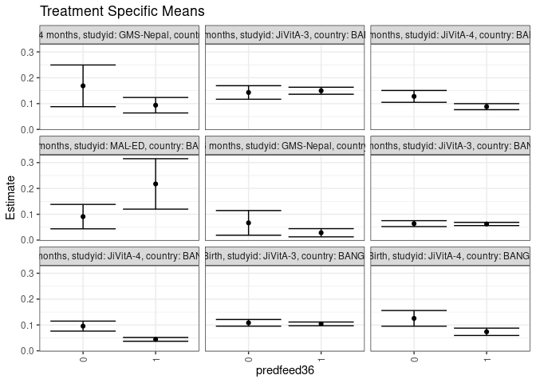

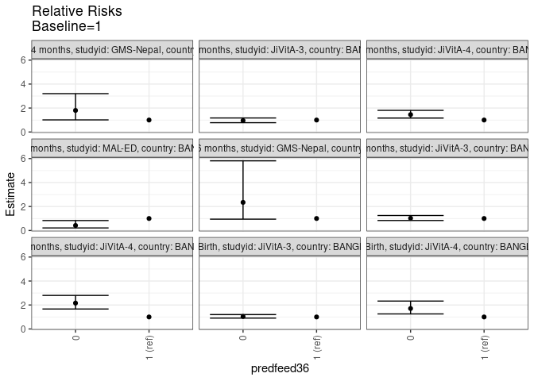

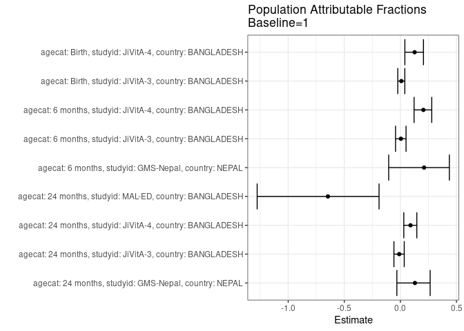

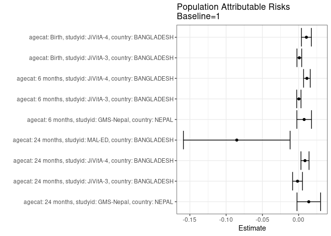

## Results Table

### Parameter: TSM

| agecat | studyid | country | intervention_level | baseline_level | estimate | ci_lower | ci_upper |
| --- | --- | --- | --- | --- | --- | --- | --- |
| Birth | JiVitA-3 | BANGLADESH | 1 | NA | 0.1040317 | 0.0967016 | 0.1113618 |
| Birth | JiVitA-3 | BANGLADESH | 0 | NA | 0.1082233 | 0.0952618 | 0.1211848 |
| Birth | JiVitA-4 | BANGLADESH | 1 | NA | 0.0735368 | 0.0593570 | 0.0877166 |
| Birth | JiVitA-4 | BANGLADESH | 0 | NA | 0.1254826 | 0.0951535 | 0.1558117 |
| 6 months | GMS-Nepal | NEPAL | 1 | NA | 0.0284360 | 0.0125625 | 0.0443096 |
| 6 months | GMS-Nepal | NEPAL | 0 | NA | 0.0666667 | 0.0189095 | 0.1144238 |
| 6 months | JiVitA-3 | BANGLADESH | 1 | NA | 0.0624905 | 0.0562543 | 0.0687267 |
| 6 months | JiVitA-3 | BANGLADESH | 0 | NA | 0.0638081 | 0.0524031 | 0.0752130 |
| 6 months | JiVitA-4 | BANGLADESH | 1 | NA | 0.0442668 | 0.0369485 | 0.0515852 |
| 6 months | JiVitA-4 | BANGLADESH | 0 | NA | 0.0954936 | 0.0761299 | 0.1148573 |
| 24 months | GMS-Nepal | NEPAL | 1 | NA | 0.0936639 | 0.0636576 | 0.1236702 |
| 24 months | GMS-Nepal | NEPAL | 0 | NA | 0.1686747 | 0.0880242 | 0.2493252 |
| 24 months | JiVitA-3 | BANGLADESH | 1 | NA | 0.1496701 | 0.1360874 | 0.1632527 |
| 24 months | JiVitA-3 | BANGLADESH | 0 | NA | 0.1430000 | 0.1167860 | 0.1692140 |
| 24 months | JiVitA-4 | BANGLADESH | 1 | NA | 0.0880583 | 0.0763279 | 0.0997887 |
| 24 months | JiVitA-4 | BANGLADESH | 0 | NA | 0.1278027 | 0.1049044 | 0.1507009 |
| 24 months | MAL-ED | BANGLADESH | 1 | NA | 0.2173913 | 0.1198376 | 0.3149450 |
| 24 months | MAL-ED | BANGLADESH | 0 | NA | 0.0909091 | 0.0436795 | 0.1381387 |

### Parameter: E(Y)

| agecat | studyid | country | intervention_level | baseline_level | estimate | ci_lower | ci_upper |
| --- | --- | --- | --- | --- | --- | --- | --- |
| Birth | JiVitA-3 | BANGLADESH | NA | NA | 0.1049527 | 0.0986146 | 0.1112909 |
| Birth | JiVitA-4 | BANGLADESH | NA | NA | 0.0842273 | 0.0714625 | 0.0969920 |
| 6 months | GMS-Nepal | NEPAL | NA | NA | 0.0360531 | 0.0201218 | 0.0519845 |
| 6 months | JiVitA-3 | BANGLADESH | NA | NA | 0.0627923 | 0.0572659 | 0.0683187 |
| 6 months | JiVitA-4 | BANGLADESH | NA | NA | 0.0556750 | 0.0484735 | 0.0628765 |
| 24 months | GMS-Nepal | NEPAL | NA | NA | 0.1076233 | 0.0788298 | 0.1364169 |
| 24 months | JiVitA-3 | BANGLADESH | NA | NA | 0.1481311 | 0.1360218 | 0.1602403 |
| 24 months | JiVitA-4 | BANGLADESH | NA | NA | 0.0968140 | 0.0862351 | 0.1073930 |
| 24 months | MAL-ED | BANGLADESH | NA | NA | 0.1320755 | 0.0863920 | 0.1777589 |

### Parameter: RR

| agecat | studyid | country | intervention_level | baseline_level | estimate | ci_lower | ci_upper |
| --- | --- | --- | --- | --- | --- | --- | --- |
| Birth | JiVitA-3 | BANGLADESH | 1 | 1 | 1.0000000 | 1.0000000 | 1.0000000 |
| Birth | JiVitA-3 | BANGLADESH | 0 | 1 | 1.0402914 | 0.9042693 | 1.1967744 |
| Birth | JiVitA-4 | BANGLADESH | 1 | 1 | 1.0000000 | 1.0000000 | 1.0000000 |
| Birth | JiVitA-4 | BANGLADESH | 0 | 1 | 1.7063930 | 1.2516804 | 2.3262943 |
| 6 months | GMS-Nepal | NEPAL | 1 | 1 | 1.0000000 | 1.0000000 | 1.0000000 |
| 6 months | GMS-Nepal | NEPAL | 0 | 1 | 2.3444444 | 0.9454214 | 5.8137246 |
| 6 months | JiVitA-3 | BANGLADESH | 1 | 1 | 1.0000000 | 1.0000000 | 1.0000000 |
| 6 months | JiVitA-3 | BANGLADESH | 0 | 1 | 1.0210839 | 0.8338198 | 1.2504049 |
| 6 months | JiVitA-4 | BANGLADESH | 1 | 1 | 1.0000000 | 1.0000000 | 1.0000000 |
| 6 months | JiVitA-4 | BANGLADESH | 0 | 1 | 2.1572261 | 1.6635401 | 2.7974224 |
| 24 months | GMS-Nepal | NEPAL | 1 | 1 | 1.0000000 | 1.0000000 | 1.0000000 |
| 24 months | GMS-Nepal | NEPAL | 0 | 1 | 1.8008505 | 1.0127956 | 3.2020896 |
| 24 months | JiVitA-3 | BANGLADESH | 1 | 1 | 1.0000000 | 1.0000000 | 1.0000000 |
| 24 months | JiVitA-3 | BANGLADESH | 0 | 1 | 0.9554349 | 0.7790577 | 1.1717435 |
| 24 months | JiVitA-4 | BANGLADESH | 1 | 1 | 1.0000000 | 1.0000000 | 1.0000000 |
| 24 months | JiVitA-4 | BANGLADESH | 0 | 1 | 1.4513421 | 1.1651956 | 1.8077599 |
| 24 months | MAL-ED | BANGLADESH | 1 | 1 | 1.0000000 | 1.0000000 | 1.0000000 |
| 24 months | MAL-ED | BANGLADESH | 0 | 1 | 0.4181818 | 0.2104857 | 0.8308215 |

### Parameter: PAR

| agecat | studyid | country | intervention_level | baseline_level | estimate | ci_lower | ci_upper |
| --- | --- | --- | --- | --- | --- | --- | --- |
| Birth | JiVitA-3 | BANGLADESH | 1 | NA | 0.0009210 | -0.0023766 | 0.0042187 |
| Birth | JiVitA-4 | BANGLADESH | 1 | NA | 0.0106905 | 0.0038266 | 0.0175543 |
| 6 months | GMS-Nepal | NEPAL | 1 | NA | 0.0076171 | -0.0024945 | 0.0177287 |
| 6 months | JiVitA-3 | BANGLADESH | 1 | NA | 0.0003018 | -0.0026444 | 0.0032481 |
| 6 months | JiVitA-4 | BANGLADESH | 1 | NA | 0.0114082 | 0.0068264 | 0.0159900 |
| 24 months | GMS-Nepal | NEPAL | 1 | NA | 0.0139594 | -0.0022828 | 0.0302016 |
| 24 months | JiVitA-3 | BANGLADESH | 1 | NA | -0.0015390 | -0.0083384 | 0.0052603 |
| 24 months | JiVitA-4 | BANGLADESH | 1 | NA | 0.0087557 | 0.0031729 | 0.0143386 |
| 24 months | MAL-ED | BANGLADESH | 1 | NA | -0.0853158 | -0.1588607 | -0.0117709 |

### Parameter: PAF

| agecat | studyid | country | intervention_level | baseline_level | estimate | ci_lower | ci_upper |
| --- | --- | --- | --- | --- | --- | --- | --- |
| Birth | JiVitA-3 | BANGLADESH | 1 | NA | 0.0087758 | -0.0231877 | 0.0397408 |
| Birth | JiVitA-4 | BANGLADESH | 1 | NA | 0.1269243 | 0.0401082 | 0.2058884 |
| 6 months | GMS-Nepal | NEPAL | 1 | NA | 0.2112746 | -0.1042928 | 0.4366642 |
| 6 months | JiVitA-3 | BANGLADESH | 1 | NA | 0.0048065 | -0.0432351 | 0.0506357 |
| 6 months | JiVitA-4 | BANGLADESH | 1 | NA | 0.2049069 | 0.1221393 | 0.2798709 |
| 24 months | GMS-Nepal | NEPAL | 1 | NA | 0.1297062 | -0.0313041 | 0.2655790 |
| 24 months | JiVitA-3 | BANGLADESH | 1 | NA | -0.0103895 | -0.0574024 | 0.0345332 |
| 24 months | JiVitA-4 | BANGLADESH | 1 | NA | 0.0904388 | 0.0304932 | 0.1466779 |
| 24 months | MAL-ED | BANGLADESH | 1 | NA | -0.6459627 | -1.2767666 | -0.1899302 |